# Radial Basis Function and K Means Clustering

Breton Shindel and Lorraine Williams

May 30, 2016

# Problem 1 (20 points)

In this problem you will use the data file “vizData.csv” (x and y denote the input and target) to visualize the effect of gamma in the RBF model on a simple data set. Use all training points in the data set as cluster centers.

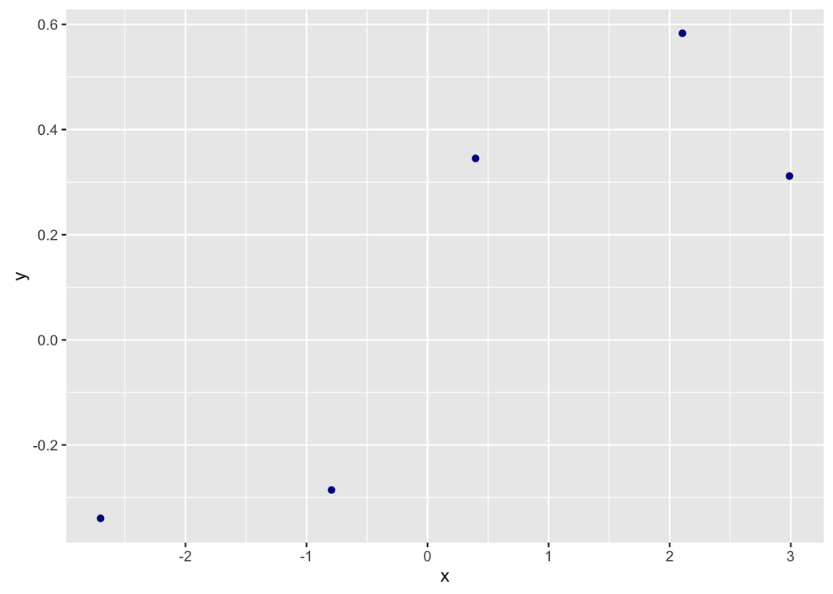

```r
setwd("~/Desktop/Analytics_Work/R_Analytics/")
library(ggplot2)

vizData = read.csv("vizData.csv")

ggplot(vizData, aes(x, y)) + geom_point(col = 'darkblue')
```

## 1.1

Create a regression RBF model with gamma equal 5. Plot the final hypothesis curve along with the training points on the same plot.

Computing the RBF matrix and weights

```r
rbf_mat = function(x, u, gamma){
  mat = matrix(nrow=length(x), ncol=length(u))
  for (c in 1:length(u)){
    for (r in 1:length(x)){
      mat[r, c] = exp(-gamma*abs(x[r] - u[c])^2)
    }
  }
  return(mat)
}

x = vizData$x
y = vizData$y
mat = rbf_mat(x, x, 5)

Ws = solve(mat)%*%y

cat('Weights: ', Ws)
```

```
## Weights:  -0.3395237 0.345409 -0.2858542 0.5771596 0.3000221
```

```r
cat('RBF matrix: ', mat)
```

```
## RBF matrix:  1 1.469893e-21 1.254801e-08 6.94078e-51 4.832303e-71 1.469893e-21 1 0.000842948 4.568202e-07 2.504253e-15 1.254801e-08 0.000842948 1 5.698715e-19 8.411458e-32 6.94078e-51 4.568202e-07 5.698715e-19 1 0.02003172 4.832303e-71 2.504253e-15 8.411458e-32 0.02003172 1
```

Hypothesis curve

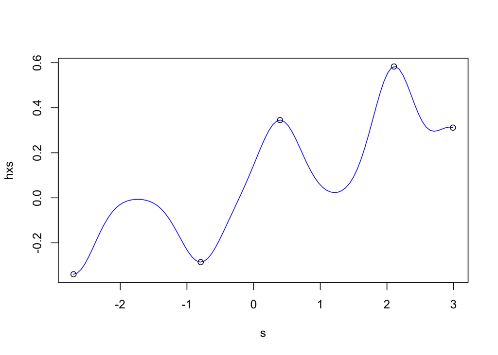

```r
s = seq(min(vizData$x), max(vizData$x), length.out=100)

hx = function(matrix, ws){
  hhat = matrix %*% ws
  return(hhat)
}

unseen = rbf_mat(s, x, 5)
hxs = hx(unseen, Ws)

plot(s, hxs, type='l', col='blue')
points(x, y)
```

## 1.2

Create a regression RBF model with gamma equal 1/5. Plot the final hypothesis curve along with the training points on the same plot.

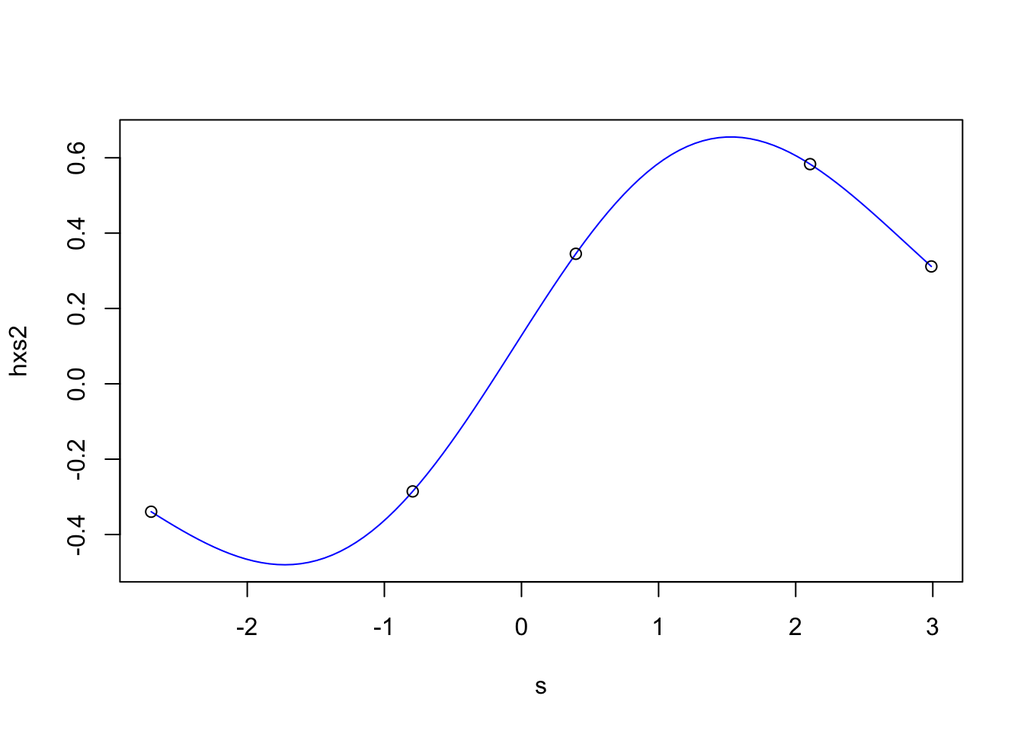

```r
mat2 = rbf_mat(x, x, 0.2)

Ws2 = solve(mat2)%*%y

unseen2 = rbf_mat(s, x, 0.2)
hxs2 = hx(unseen2, Ws2)

plot(s, hxs2, type='l', col='blue')
points(x, y)
```

## 1.3

Explain your observations.

```
As gamma decreases, the hypothesis curve becomes smoother, while as gamma increases, the hypothesis curve gets bumpier as the function approaches each point. This is likely because the gamma level controls how much of an impact each input value has on the output value. Gamma acts as a scalar, so a smaller gamma will allow further input points to influence the hypothesis output more, where as a larger gamma level will limit the effect of further input points on the hypothesis output. This is why the RBF takes the form of a Gaussian, with the x axis as the distance between an input and a center and the y axis as the impact on the hypothesis output of a point at that distance. Gamma makes the gaussian wider if it is smaller, and skinnier if it is larger.
```

# Problem 2 (20 points)

In this problem you will use the data file “kMeansData.csv” (x1 and x2 denote the input features) to create 3 clusters using unsupervised Lloyd’s k-means algorithm. The training should only stop if the difference between the cluster center locations in two consecutive iterations is less than 0.001 or if the number of iterations has reached 1000. For the initial selection of cluster locations choose 3 points from the data set randomly.

```r
kmData = read.csv("kMeansData.csv")

# initialize cluster dentroids
centers = matrix(c(runif(3, 1, 7), runif(3, 0, 2.5), c(1, 2, 3)), nrow=3, ncol=3)

# Assign input values to nearest centroid class labels
CL = function(inputs, centroid){

  # initialize storage matrix
  mat = matrix(0, nrow=nrow(inputs), ncol=nrow(centroid))

  # calculate euclidean distances of inputs with each centroid
  for (i in 1:nrow(inputs)){
    for (j in 1:nrow(centroid)){
      mat[i, j] = sqrt((inputs[i,1]-centroid[j,1])^2 + (inputs[i,2]-centroid[j,2])^2)
    }
  }

  # create a new column; take the min value of each row for that column
  mat = cbind(mat, unlist(apply(mat, 1, min)))

  # initialize class label storage vector
  cls = {}

  # go through each column of the matrix and match it with the minimum value's column
  # add the vector onto the matrix
  for (i in 1:nrow(mat)){
    mat2 = unlist(match(mat[i,ncol(mat)], mat[i,1:nrow(centroid)]))
    cls = c(cls, mat2)
  }
  mat = cbind(mat, cls)
  return(mat)
}

# calculate true centroids
Cent_Up = function(inputs, centroid){

  # initialize S
  S = matrix(0, nrow=nrow(inputs), ncol=(ncol(inputs)))

  # just bear with this
  Cent_New = centroid

  # calculate and assign distances, combine labels with kmData, iterate through
  for (i in 1:1000){
    dists = CL(inputs, centroid)
    new_data = cbind(inputs, dists[,ncol(dists)])

    # set S as subset of distances in k, calculate new centroid
    for (k in 1:nrow(centroid)){
      S = new_data[(new_data[,3] %in% k), 1:2]
      Cent_New[k, 1:2] = colMeans(S)

    }
   # set stopping criteria
   if (sum(abs(Cent_New[,1:2] - centroid[,1:2])) < 0.001){
     print(i)
     break
      }
    centroid = Cent_New
  }
  return(centroid)
}

cent2 = Cent_Up(kmData, centers)
```

```
## [1] 6
```

```r
data2 = CL(kmData, cent2)
Classified = cbind(kmData, data2[,5])
```

After convergence, report the final cluster centers. Plot the 3 clusters in different colors with cluster centers clearly marked on the plot.

```r
cat('Final cluster centers (x, y): ', cent2[1, 1:2], cent2[2, 1:2], cent2[3, 1:2])
```

```
## Final cluster centers (x, y):  4.292593 1.359259 5.626087 2.047826 1.462 0.246
```

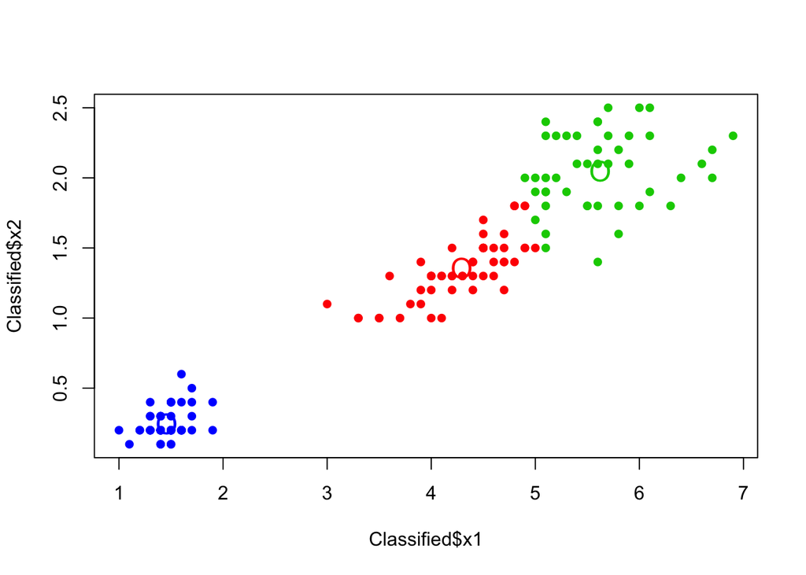

```r
plot(Classified$x1, Classified$x2, pch=16, col=Classified[,3]+1)
points(cent2[,1], cent2[,2], pch='O', col=cent2[,3]+1, cex=1.5)
```

# Problem 3 (30 points)

In this problem you will use the data file “rbfClassification.csv” to create an RBF classification model. x1 and x2 denote the input features and cls denotes the target class of the corresponding data points.

```r
rbfData = read.csv("rbfClassification.csv")

rbf_input = rbfData[,-3]
rbf_input
```

```
##            x1         x2
## 1  -2.4272359  1.9659838
## 2   2.3826046  2.2566141
## 3  -2.6806677  2.3799790
## 4  -2.6202771  2.9138230
## 5   1.5137921 -2.3126499
## 6   2.4608937 -2.2952887
## 7   0.9219945 -2.6851119
## 8  -0.5053792 -2.3014167
## 9  -0.2799112 -0.5208695
## 10 -1.7423655  2.9690978
## 11  2.6171876  0.9290693
## 12  1.9577334  2.4596804
## 13  2.1781970 -2.4451385
## 14 -0.7366801 -1.3830436
## 15 -0.5872145  2.2874561
## 16  2.2522043  1.0818026
## 17  0.4649106  1.5804934
## 18 -2.8362998  0.7867402
## 19  1.7557883  0.7805419
## 20 -2.9269759  1.5830277
```

## 3.1

Use k-means clustering to determine the location of 2 cluster centers that you will use in your RBF model. Report the coordinate of the cluster centers.

```r
Centers = matrix(c(runif(2, -3, 3), runif(2, -3, 3), c(0, 1)), nrow=2, ncol=3)

CL(rbf_input, Centers)
```

```
##                                     cls
##  [1,] 1.8866076 5.3773006 1.8866076   1
##  [2,] 5.6917505 0.9642400 0.9642400   2
##  [3,] 2.2509787 5.6818324 2.2509787   1
##  [4,] 2.7881811 5.7338169 2.7881811   1
##  [5,] 5.0501228 4.0285944 4.0285944   2
##  [6,] 5.8888162 3.7842347 3.7842347   2
##  [7,] 4.7533574 4.6044308 4.6044308   2
##  [8,] 3.4202196 5.0917470 3.4202196   1
##  [9,] 2.7029442 3.7688286 2.7029442   1
## [10,] 3.0572990 4.9063687 3.0572990   1
## [11,] 5.5742188 0.6145193 0.6145193   2
## [12,] 5.3840403 1.3917214 1.3917214   2
## [13,] 5.6990189 3.9763587 3.9763587   2
## [14,] 2.6462734 4.6369256 2.6462734   1
## [15,] 3.1568091 3.6095130 3.1568091   1
## [16,] 5.2384686 0.7729892 0.7729892   2
## [17,] 3.6611594 2.4642536 2.4642536   2
## [18,] 0.6501577 5.8017503 0.6501577   1
## [19,] 4.7005345 1.3534769 1.3534769   2
## [20,] 1.4434668 5.8544916 1.4434668   1
```

```r
Centers2 = Cent_Up(rbf_input, Centers)
```

```
## [1] 4
```

```r
cat('New cluster centers: ', Centers2[1, 1:2], Centers2[2, 1:2])
```

```
## New cluster centers:  -2.260148 2.126587 1.30641 -0.3734859
```

## 3.2

Train an RBF model using γ = 0.5. Report the correct classification rate of your model.

```r
X = sqrt((rbf_input[,1] - rbf_input[,2])^2)
ones = rep(1, nrow(rbf_input))

Us = sqrt((Centers2[,1] - Centers[,2])^2)

phi = matrix(c(ones, rbf_mat(X, Us, 0.5)), nrow=20, ncol=3)
y = rbfData[,3]

W3s = solve(t(phi)%*%phi)%*%t(phi)%*%y

yhat = round(hx(phi, W3s), 0)

Acc = mean(yhat == y)

cat('Correct classification rate:', Acc)
```

```
## Correct classification rate: 0.75
```

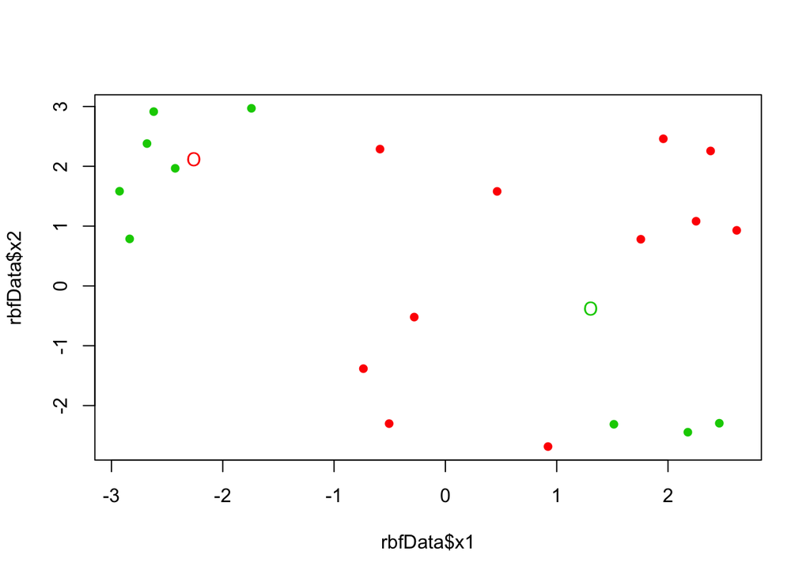

```r
plot(rbfData$x1, rbfData$x2, col=yhat+2, pch=16)
points(Centers2[,1], Centers2[,2], col=Centers2[,3]+2, pch='O')
```

# Problem 4 (30 points)

In this problem you will use hold-out validation (80% − 20%) to select number of cluster centers for an RBF classifier model. You will be using “healthcare- Train.csv” and “healthcareTest.csv” data sets to predict the pdc-80-flag using the following continuous features: total-los, num-op, num-er, num-ndc, pre- total-cost, and pre-CCI.

Setting up the data

```r
healthTrain = read.csv("healthcareTrain.csv")
healthTest = read.csv("healthcareTest.csv")

Train = data.frame(c(healthTrain["total_los"], healthTrain["num_op"],
                     healthTrain["num_er"], healthTrain["num_ndc"],
                     healthTrain["pre_total_cost"], healthTrain["pre_CCI"],
                     healthTrain["pdc_80_flag"]))

Test = data.frame(c(healthTest["total_los"], healthTest["num_op"],
                    healthTest["num_er"], healthTest["num_ndc"],
                    healthTest["pre_total_cost"], healthTest["pre_CCI"],
                    healthTest["pdc_80_flag"]))

TrainFull = data.frame(c(healthTrain["total_los"], healthTrain["num_op"],
                         healthTrain["num_er"], healthTrain["num_ndc"],
                         healthTrain["pre_total_cost"], healthTrain["pre_CCI"],
                         healthTrain["pdc_80_flag"]))

holdout_partition = function(train){
  # randomized integers 1-n, by 20% of n
  ind = sample(1:dim(train)[1], dim(train)[1]*0.2)
  for (i in train){
    return(train[ind,]) # return the randomized n*0.2 index values
  }
}

Val = holdout_partition(Train)
Train = Train[-(match(Val[,1], Train[,1])),]

head(Train)
```

```
##   total_los num_op num_er num_ndc pre_total_cost pre_CCI pdc_80_flag
## 2         0      6      0      10       861.6986       0           1
## 3         0      6      0       1      3359.2931       0           0
## 4         0      0      0       2       243.8051       0           0
## 5         0      2      0       1       925.5190       0           1
## 6         0      9      0       4     24631.4679       1           1
## 7         0      2      0       2      5526.6127       1           1
```

## 4.1

Use rbf function in R to create your RBF model. Try cluster numbers 5 to 25. Use your hold-out validation set to figure out the best number of clusters. Report the best number of clusters and the corresponding validation accuracy rate.

```r
library(RSNNS)
# AccStore = matrix(0, 20, 1)
AccStore = list()

for (i in 5:25){
  rbf_model = rbf(Train[,1:6], matrix(Train[,7]), size=i, maxit=1000, linOut=FALSE)
  Yhat = round(predict(rbf_model, Val[,1:6]))
  Accuracy = mean(Yhat == Val[,7])
  AccStore[i] = Accuracy
}

BestCentroidNum = which.max(unlist(AccStore))+4
# add 4 because we started our iteration at 5.

cat('Highest performing centroid numbers: ', BestCentroidNum)
```

```
## Highest performing centroid numbers:  15
```

```r
cat('Corresponding Accuracy: ', AccStore[[BestCentroidNum]])
```

```
## Corresponding Accuracy:  0.5818182
```

## 4.2

Plot the accuracy rate vs. number of cluster centers.

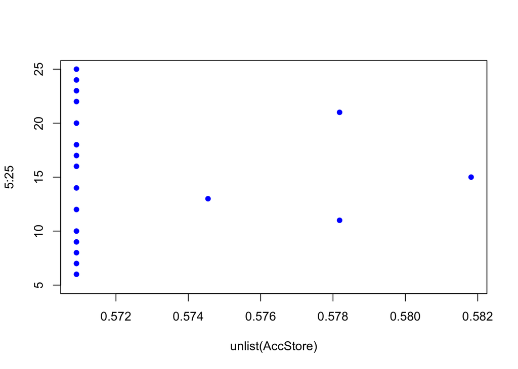

```r
plot(unlist(AccStore), 5:25, col='blue', pch=16)
```

## 4.3

Use the model with the best performance to predict the pdc-80-flag for the test set. How does your validation accuracy rate compare to test accuracy rate?

```r
rbf_model_test = rbf(TrainFull[,1:6], matrix(TrainFull[,7]),
                     size=BestCentroidNum, maxit=1000, linOut=FALSE)

YhatTest = round(predict(rbf_model, Test[,1:6]))

AccTest = mean(YhatTest == Test[,7])
cat('Test Accuracy: ', AccTest)
```

```
## Test Accuracy:  0.625
```

[output not shown]